# L4 - Data Transformation & Summarization

## Lecture Goals

- Learn how to:
  - Transform data
  - Summarize data
  - Perform these operations by groups
- Readings
  - [R4DS](http://r4ds.had.co.nz/): ch. 5.5-5.7, 12, 18
  - Data Wrangling [cheatsheet](https://www.rstudio.com/wp-content/uploads/2015/02/data-wrangling-cheatsheet.pdf)

## Manipulating Data

- Often need to *modify* original data (i.e. apply functions)
- Two basic types of functions

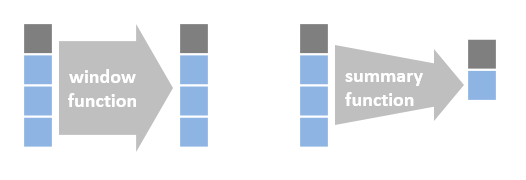

  - **Window functions** operate *across rows/observations*; take in vectors and return (same size) vectors
  - **Summary functions** operate *over columns/variables*; take vectors and return single values

## Transforming Data

- `mutate()` appends new variable/column to data

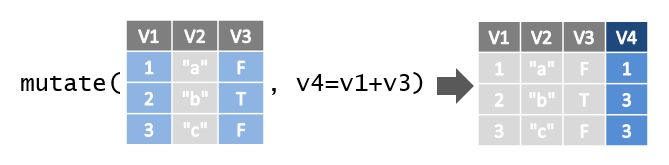

  - `transmute()` only keeps new variable

## Transforming Data

- Window functions use *vectorised operations*

```r
data_frame(V1=1:3) %>% transmute(V2=V1*(1:2))
## Warning in V1 * (1:2): longer object length is not a multiple of shorter
## object length
## # A tibble: 3 x 1
##      V2
##   <int>
## 1     1
## 2     4
## 3     3
```

## Example

- Use `mutate()` + `replace()` to change/fix data values

```r
data_frame(V1 = 1:3, V2 = c("a","N/A","b")) %>%
  mutate(V2 = replace(V2, V2=="N/A", NA) ) %>%
  mutate(V1 = replace(V1, V2=="a", 5) )
## # A tibble: 3 x 2
##      V1 V2
##   <dbl> <chr>
## 1     5 a
## 2     2 <NA>
## 3     3 b
```

## Summarising Data

- `summarise()` creates new data-frame with summary value(s)

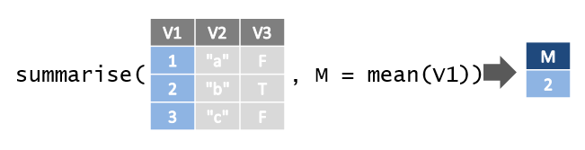

- E.g. number of distinct restaurants inspected

```r
dinesafe %>%
  filter(ESTABLISHMENTTYPE == "Restaurant") %>%
  summarise(n_dist_rest = n_distinct(ESTABLISHMENT_ID))
## # A tibble: 1 x 1
##   n_dist_rest
##         <int>
## 1        6977
```

## Example

- Finding range of inspection dates

```r
range(dinesafe$INSPECTION_DATE)
## [1] "2016-09-23" "2018-09-21"
dinesafe %>% summarise( MIN_DATE = min(INSPECTION_DATE),
                        MAX_DATE = max(INSPECTION_DATE))
## # A tibble: 1 x 2
##   MIN_DATE   MAX_DATE
##   <date>     <date>
## 1 2016-09-23 2018-09-21
```

## Grouping

- Apply summary functions to **groups**, i.e. subsets of data

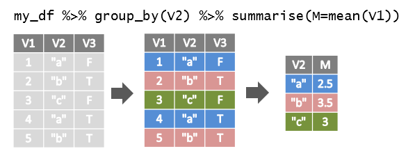

  - Result contains *group indentifier*, i.e. unique group values
- `group_by()` does not alter data
  - `ungroup()` removes grouping

## Example

```r
my_df %>% group_by(V2) %>% slice(1)
## # A tibble: 3 x 3
## # Groups:   V2 [3]
##      V1 V2    V3
##   <int> <chr> <lgl>
## 1     1 a     FALSE
## 2     2 b     TRUE
## 3     3 c     FALSE

my_df %>% group_by(V2) %>% ungroup() %>% slice(1)
## # A tibble: 1 x 3
##      V1 V2    V3
##   <int> <chr> <lgl>
## 1     1 a     FALSE
```

## Example

```r
dinesafe %>%
  group_by(ESTABLISHMENTTYPE) %>%
  summarise( n_distinct(ESTABLISHMENT_ID) )
## # A tibble: 55 x 2
##    ESTABLISHMENTTYPE                 `n_distinct(ESTABLISHMENT_ID)`
##    <chr>                                                      <int>
##  1 Bake Shop                                                     46
##  2 Bakery                                                       381
##  3 Banquet Facility                                             151
##  4 Bed & Breakfast                                                1
##  5 Boarding / Lodging Home - Kitchen                             67
##  6 Bottling Plant                                                 5
##  7 Brew Your Own Beer / Wine                                      5
##  8 Butcher Shop                                                 157
##  9 Cafeteria                                                    186
## 10 Cafeteria - Public Access                                    107
## # ... with 45 more rows
```

## Multiple Grouping

- Grouping on *multiple* variables
  - Each *unique combination* becomes a group
  - Each summary operation *removes* last grouping variable

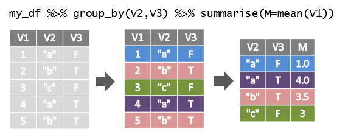

## Multiple Grouping

```r
my_df %>% group_by(V2,V3) %>% summarise(M=mean(V1))
## # A tibble: 4 x 3
## # Groups:   V2 [3]
##   V2    V3        M
##   <chr> <lgl> <dbl>
## 1 a     FALSE   1
## 2 a     TRUE    4
## 3 b     TRUE    3.5
## 4 c     FALSE   3

my_df %>% group_by(V2,V3) %>% summarise(M=mean(V1)) %>%
  summarise(MM=mean(M))
## # A tibble: 3 x 2
##   V2       MM
##   <chr> <dbl>
## 1 a       2.5
## 2 b       3.5
## 3 c       3
```

## Transforming with Groups

- Summary functions can be used inside window functions, with vectorisation and *recycling*

```r
my_df %>% group_by(V2) %>%
  mutate( group_percent = V1 / sum(V1))
## # A tibble: 5 x 4
## # Groups:   V2 [3]
##      V1 V2    V3    group_percent
##   <int> <chr> <lgl>         <dbl>
## 1     1 a     FALSE         0.2
## 2     2 b     TRUE          0.286
## 3     3 c     FALSE         1
## 4     4 a     TRUE          0.8
## 5     5 b     TRUE          0.714
```